# Practical Machine Learning Assignment

Sytze

12-10-2018

### Coursera Data Science Specialisation

### Course #8

Using devices such as Jawbone Up, Nike FuelBand, and Fitbit it is now possible to collect a large amount of data about personal activity relatively inexpensively. These type of devices are part of the quantified self movement – a group of enthusiasts who take measurements about themselves regularly to improve their health, to find patterns in their behavior, or because they are tech geeks. One thing that people regularly do is quantify how much of a particular activity they do, but they rarely quantify how well they do it. In this project, we will use data from accelerometers on the belt, forearm, arm, and dumbell of 6 participants. They were asked to perform barbell lifts correctly and incorrectly in 5 different ways. More information is available from the website here: http://web.archive.org/web/20161224072740/http:/groupware.les.inf.puc-rio.br/har (see the section on the Weight Lifting Exercise Dataset). We will build a model to predict the way the barbell is lift.

First, we library the needed packages.

```r
library(ggplot2); library(caret); library(dplyr); library(rattle);
library(parallel); library(doParallel); options(digits = 4)
```

Then we download the data.

```r
training <- read.csv(url("https://d396qusza40orc.cloudfront.net/predmachlearn/pml-training.csv"),
                     na.strings = c("NA", "", "#DIV/0!"))
validation <- read.csv(url("https://d396qusza40orc.cloudfront.net/predmachlearn/pml-testing.csv"),
                       na.strings = c("NA", "", "#DIV/0!"))
```

And have a look at the training dataset. This is a large dataset, so results are not shown in the markdown file.

```r
str(training)
```

It appears that the first columns have metadata that are not needed for analysis. There are also many NA’s. We remove these columns from the dataset to get tidy data.

```r
training <- select(training,
      -X, -raw_timestamp_part_1,-raw_timestamp_part_2,
      -cvtd_timestamp, -new_window, -num_window)
training <- training[,colSums(is.na(training))==0]
```

Then we split the training dataset in two, one for training and one for testing.

```r
set.seed(12345)
inTrain <- createDataPartition(y=training$classe,
                               p=0.7, list = F)
testing <- training[-inTrain,]
training <- training[inTrain,]
dim(training); dim(testing)
```

```
## [1] 13737    54
```

```
## [1] 5885   54
```

We will build three different models and test them for accuracy. First we build a decision tree model.

```r
modFitTrees <- train(data = training, classe ~ ., method = "rpart")
```

Let’s make a figure of the tree to see what it looks like.

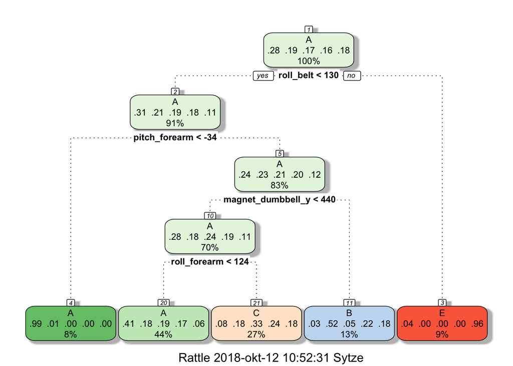

```r
fancyRpartPlot(modFitTrees$finalModel)
```

Now we’ll test the model with the testing set.

```r
predTrees <- predict(modFitTrees, newdata = testing)
cmTrees <- confusionMatrix(predTrees, testing$classe)
cmTrees$table
```

```
##           Reference
## Prediction    A    B    C    D    E
##          A 1494  470  467  438  141
##          B   21  380   29  184  147
##          C  128  289  530  342  277
##          D    0    0    0    0    0
##          E   31    0    0    0  517
```

```r
cmTrees$overall[1]
```

```
## Accuracy
##   0.4963
```

The accuracy of this model is clearly very low, 0.4963. The out of sample error is 0.5037. We need a better model than this. Now let’s try a Bagging model and test in on the testing data set.

```r
modFitBagging <- train(data = training, classe ~ ., method = "treebag")
predBagging <- predict(modFitBagging, newdata = testing)
cmBagging <- confusionMatrix(predBagging, testing$classe)
cmBagging$table
```

```
##           Reference
## Prediction    A    B    C    D    E
##          A 1667   17    2    3    1
##          B    7 1111    5    1    4
##          C    0    8 1013   17    2
##          D    0    0    6  941    6
##          E    0    3    0    2 1069
```

```r
cmBagging$overall[1]
```

```
## Accuracy
##   0.9857
```

This model is already much better, with an accuracy of 0.9857. This means that for this model the out of sample error is 0.0143. The final model we try is a random forest model. Building this model can take quite a while, so we use extra cores as described here: “https://github.com/lgreski/datasciencectacontent/blob/master/markdown/pml-randomForestPerformance.md”. We will also create a training control to further improve speed. Then we’ll test the model with the testing data set.

```r
cluster <- makeCluster(detectCores()-1)
registerDoParallel(cluster)
tc <- trainControl(method = "cv", number = 5, allowParallel = T)
modFitRF <- train(data = training, classe ~ ., method = "rf", trControl = tc)
stopCluster(cluster); registerDoSEQ()
predRF <- predict(modFitRF, newdata = testing)
cmRF <- confusionMatrix(predRF, testing$classe)
cmRF$table
```

```
##           Reference
## Prediction    A    B    C    D    E
##          A 1672   13    0    0    0
##          B    2 1121   18    0    0
##          C    0    5 1005   25    0
##          D    0    0    3  939    3
##          E    0    0    0    0 1079
```

```r
cmRF$overall[1]
```

```
## Accuracy
##   0.9883
```

The accuracy of the random forest model is 0.9883. The out of sample error is 0.0117. This makes it the best model of the three. We will use this model to predict the way the barbell was lift for the 20 cases in the validation data set.

```r
predVal <- predict(modFitRF, newdata = validation)
print(predVal)
```

```
##  [1] B A B A A E D B A A B C B A E E A B B B
## Levels: A B C D E
```